# Incorporating horizontal factor (aspect) into Least Cost Path calculation

Joseph Lewis

25 December 2018

### Loading Libraries

```r
library(raster)
library(gdistance)
```

### Create example raster

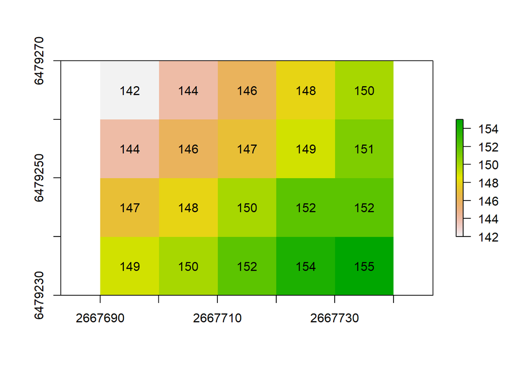

```r
r <- raster(system.file("external/maungawhau.grd", package="gdistance"))

r <- crop(r, extent(  2667690 , 2667739, 6479230 ,  6479274))

plot(r)
text(r)
```

### Compute aspect

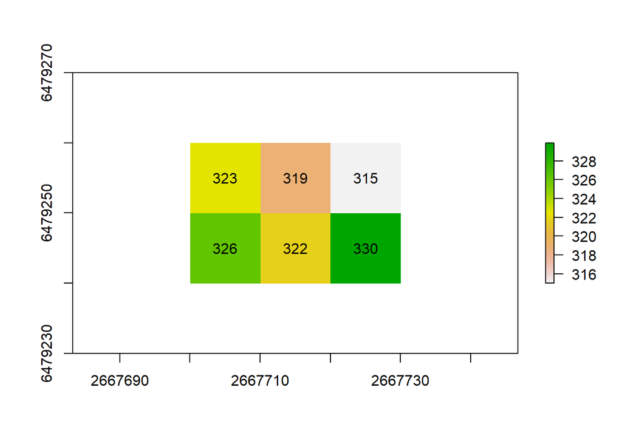

```r
aspect <- terrain(r, opt = 'aspect', unit = 'degrees', neighbors = 8)

plot(aspect)
text(aspect)
```

### Create transition layer

Using the calculated aspect raster, we know the horizontal direction for each cell (this technicaly will be the aspetct value + 90, but that’s not needed for the following calculations).

Once the horizontal direction has been ascertained, the position of ‘to’ cell relative to the horizontal direction must be calculated. This is calculated by computing the value difference between the neighbouring cell and the ‘from’ cell. If the value is 0 then the aspect hasn’t changed, and therefore, the horizontal direction hasn’t changed. This value is known as the horizontal relative moving angle (HRMA).

To ensure that the computed values are between 0 and 180, we need to minus 180 if the computed difference in the neighbouring cell and the ‘from’ cell is greater than 180. Finding the absolute value also ensures that the returned value is aways positive.

For example:

- 360 - 250 = 110
- 360 - 10 = 350; 350 - 180 = 170
- 10 - 250 = 240; 240 - 180 = 60
- 40 - 50 = -10; abs(-10) = 10

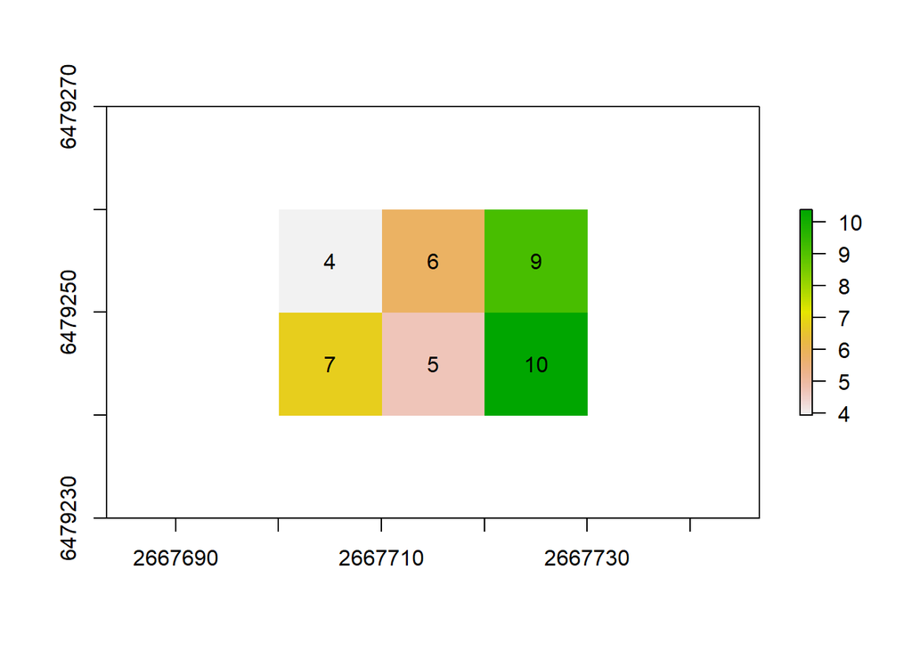

```r
altDiff <- function(x) {
  if(  abs(x[2] - x[1]) > 180) {
    abs(x[2] - x[1]) - 180
  } else {
  abs(x[2] - x[1])
    }
}

trans <- gdistance::transition(aspect, altDiff, 16)

plot(raster(trans))
text(raster(trans))
```

### Understanding transition layers

The above raster representantion of the transition layer is the average value of the value difference between the neighbouring cells and the ‘from’ cell. If we look at the transition layer, we can see the value difference to each neighbouring cell

In the transition layer, the column number denotes the cell, with the rows denoting the neighbouring cells. ‘.’ means that the cell isn’t neighbouring any other cell.

```r
round(transitionMatrix(trans), 3)
```

```
## 20 x 20 sparse Matrix of class "dsCMatrix"
##
##  [1,] . . . . . . .      .      .     . .  .     .      .     . . . . . .
##  [2,] . . . . . . .      .      .     . .  .     .      .     . . . . . .
##  [3,] . . . . . . .      .      .     . .  .     .      .     . . . . . .
##  [4,] . . . . . . .      .      .     . .  .     .      .     . . . . . .
##  [5,] . . . . . . .      .      .     . .  .     .      .     . . . . . .
##  [6,] . . . . . . .      .      .     . .  .     .      .     . . . . . .
##  [7,] . . . . . . .      3.781  .     . .  3.715 0.885  7.337 . . . . . .
##  [8,] . . . . . . 3.781  .      3.814 . .  7.496 2.896 11.117 . . . . . .
##  [9,] . . . . . . .      3.814  .     . . 11.310 6.710 14.931 . . . . . .
## [10,] . . . . . . .      .      .     . .  .     .      .     . . . . . .
## [11,] . . . . . . .      .      .     . .  .     .      .     . . . . . .
## [12,] . . . . . . 3.715  7.496 11.310 . .  .     4.600  .     . . . . . .
## [13,] . . . . . . 0.885  2.896  6.710 . .  4.600 .      8.222 . . . . . .
## [14,] . . . . . . 7.337 11.117 14.931 . .  .     8.222  .     . . . . . .
## [15,] . . . . . . .      .      .     . .  .     .      .     . . . . . .
## [16,] . . . . . . .      .      .     . .  .     .      .     . . . . . .
## [17,] . . . . . . .      .      .     . .  .     .      .     . . . . . .
## [18,] . . . . . . .      .      .     . .  .     .      .     . . . . . .
## [19,] . . . . . . .      .      .     . .  .     .      .     . . . . . .
## [20,] . . . . . . .      .      .     . .  .     .      .     . . . . . .
```

#### Cell Fourteen in detail

Cell Fourteen in the raster representation has a value of 10 This is calculated by:

```r
round(transitionMatrix(trans), 3)[14,]
```

```
##  [1]  0.000  0.000  0.000  0.000  0.000  0.000  7.337 11.117 14.931  0.000
## [11]  0.000  0.000  8.222  0.000  0.000  0.000  0.000  0.000  0.000  0.000
```

```r
cell_sum <- sum(transitionMatrix(trans)[14,])

cell_sum
```

```
## [1] 41.60711
```

```r
cell_neighbours <- sum(transitionMatrix(trans)[14,] > 0)

cell_neighbours
```

```
## [1] 4
```

```r
cell_sum / cell_neighbours
```

```
## [1] 10.40178
```

### Checking the transition values make sense

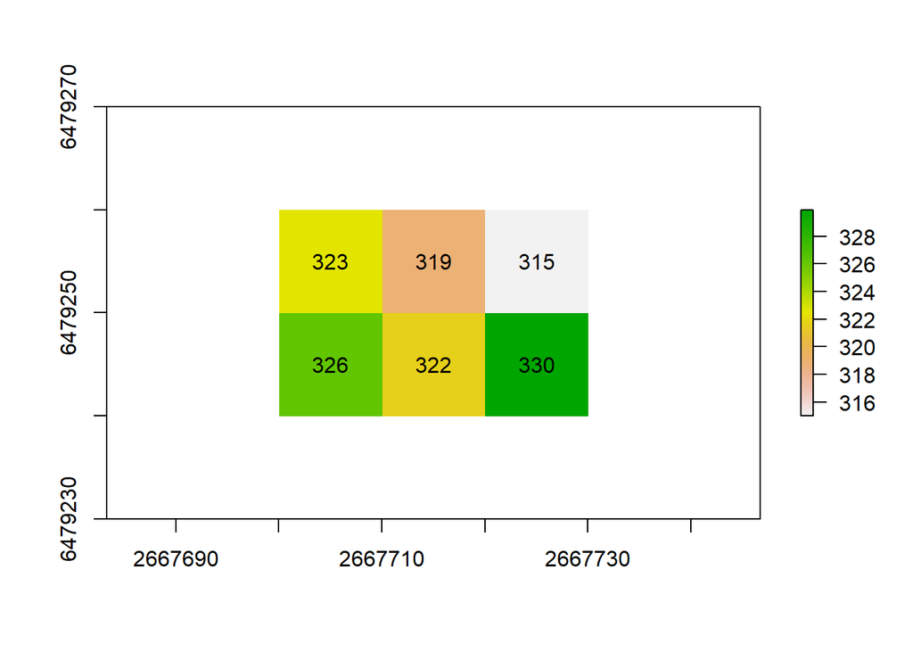

```r
plot(aspect)
text(aspect)
```

```r
round(transitionMatrix(trans), 3)[7,]
```

```
##  [1] 0.000 0.000 0.000 0.000 0.000 0.000 0.000 3.781 0.000 0.000 0.000
## [12] 3.715 0.885 7.337 0.000 0.000 0.000 0.000 0.000 0.000
```

```r
round(transitionMatrix(trans), 3)[7,13]
```

```
## [1] 0.885
```

### Reclassifying transition values

The current transition values are based on the value difference between the neighbouring cells and the ‘from’ cell. We need to reclassify the values to denote the increase/decrease in cost caused by the change in aspect (ie. the horizontal factor)

The horizontal factor is determined by a straight line with the slope 0.5/45 and intercept of 0.5.

For example:

- [slope] * value difference between neighbouring cell and ‘from’ cell + [intercept] = horizontal factor.
- (0.5 / 45) * 10.5 + 0.5 = 0.6166667
- (0.5 / 45) * 180 + 0.5 = 2.5

```r
trans_reclass <- trans

for (i in 1:length(transitionMatrix(trans_reclass))) {
  transitionMatrix(trans_reclass)[i] <- (0.5 / 45) * transitionMatrix(trans_reclass)[i] + 0.5
}
```

As seen, the transition values are now the horizontal factor values based on the above slope and intercept line.

```r
round(transitionMatrix(trans), 3)[7,8]
```

```
## [1] 3.781
```

```r
(0.5 / 45) * transitionMatrix(trans)[7,8] + 0.5 == transitionMatrix(trans_reclass)[7,8]
```

```
## [1] TRUE
```

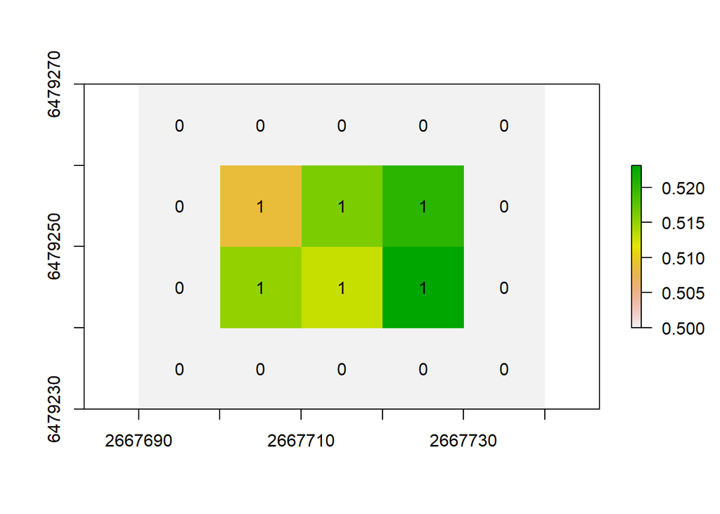

```r
plot(raster(trans_reclass))
text(raster(trans_reclass))
```

```r
round(transitionMatrix(trans_reclass), 3)
```

```
## 20 x 20 sparse Matrix of class "dgCMatrix"
##
##  [1,] 0.5 0.5 0.5 0.5 0.5 0.5 0.500 0.500 0.500 0.5 0.5 0.500 0.500 0.500
##  [2,] 0.5 0.5 0.5 0.5 0.5 0.5 0.500 0.500 0.500 0.5 0.5 0.500 0.500 0.500
##  [3,] 0.5 0.5 0.5 0.5 0.5 0.5 0.500 0.500 0.500 0.5 0.5 0.500 0.500 0.500
##  [4,] 0.5 0.5 0.5 0.5 0.5 0.5 0.500 0.500 0.500 0.5 0.5 0.500 0.500 0.500
##  [5,] 0.5 0.5 0.5 0.5 0.5 0.5 0.500 0.500 0.500 0.5 0.5 0.500 0.500 0.500
##  [6,] 0.5 0.5 0.5 0.5 0.5 0.5 0.500 0.500 0.500 0.5 0.5 0.500 0.500 0.500
##  [7,] 0.5 0.5 0.5 0.5 0.5 0.5 0.500 0.542 0.500 0.5 0.5 0.541 0.510 0.582
##  [8,] 0.5 0.5 0.5 0.5 0.5 0.5 0.542 0.500 0.542 0.5 0.5 0.583 0.532 0.624
##  [9,] 0.5 0.5 0.5 0.5 0.5 0.5 0.500 0.542 0.500 0.5 0.5 0.626 0.575 0.666
## [10,] 0.5 0.5 0.5 0.5 0.5 0.5 0.500 0.500 0.500 0.5 0.5 0.500 0.500 0.500
## [11,] 0.5 0.5 0.5 0.5 0.5 0.5 0.500 0.500 0.500 0.5 0.5 0.500 0.500 0.500
## [12,] 0.5 0.5 0.5 0.5 0.5 0.5 0.541 0.583 0.626 0.5 0.5 0.500 0.551 0.500
## [13,] 0.5 0.5 0.5 0.5 0.5 0.5 0.510 0.532 0.575 0.5 0.5 0.551 0.500 0.591
```

[output cut: 28 more lines]

### Applying Horizontal Factor to Slope

Create Slope transition layer.

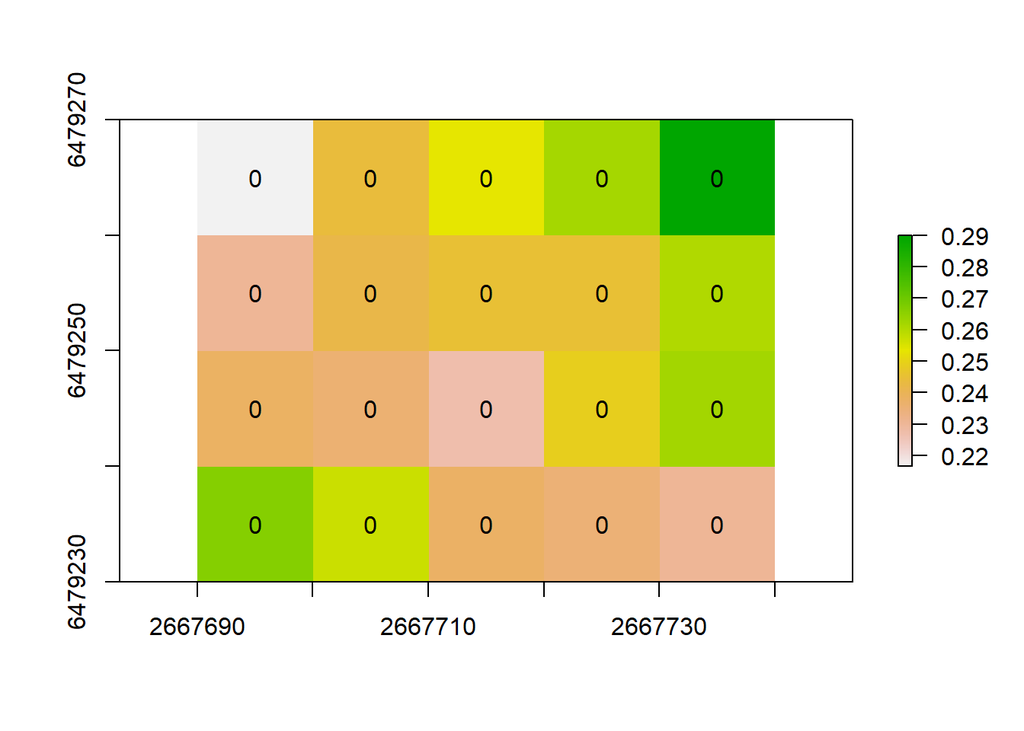

```r
altDiff <- function(x) {
  x[2] - x[1]
}

hd_alt <- gdistance::transition(r, altDiff, 8)

slope <- gdistance::geoCorrection(hd_alt)

adj <- raster::adjacent(r, cells = 1:ncell(r), pairs = TRUE, directions = 16)

slope[adj] <- 6 * exp(-3.5 * abs(slope[adj] + 0.05))

slope <- gdistance::geoCorrection(slope)

plot(raster(slope))
text(raster(slope))
```

#### Create final cost transition layer

The horizontal factor values are applied to the slope values. Only where we have transition slope layer values is the horizontal factor values applied.

```r
final_cost <- slope * trans_reclass
```

```r
round(transitionMatrix(slope), 3)
```

```
## 20 x 20 sparse Matrix of class "dsCMatrix"
##
##  [1,] .     0.250 .     .     .     0.250 0.132 0.225 .     .     .
##  [2,] 0.250 .     0.250 .     .     0.356 0.250 0.170 0.225 .     0.225
##  [3,] .     0.250 .     0.250 .     0.225 0.356 0.355 0.170 0.225 .
##  [4,] .     .     0.250 .     0.250 .     0.225 0.395 0.355 0.170 .
##  [5,] .     .     .     0.250 .     .     .     0.225 0.395 0.355 .
##  [6,] 0.250 0.356 0.225 .     .     .     0.250 .     .     .     0.176
##  [7,] 0.132 0.250 0.356 0.225 .     0.250 .     0.355 .     .     0.278
##  [8,] 0.225 0.170 0.355 0.395 0.225 .     0.355 .     0.250 .     0.225
##  [9,] .     0.225 0.170 0.355 0.395 .     .     0.250 .     0.250 .
## [10,] .     .     0.225 0.170 0.355 .     .     .     0.250 .     .
## [11,] .     0.225 .     .     .     0.176 0.278 0.225 .     .     .
## [12,] 0.225 .     0.225 .     .     0.132 0.250 0.278 0.225 .     0.355
## [13,] .     0.225 .     0.225 .     0.225 0.132 0.176 0.278 0.225 .
```

[output cut: 28 more lines]

```r
round(transitionMatrix(trans_reclass), 3)
```

```
## 20 x 20 sparse Matrix of class "dgCMatrix"
##
##  [1,] 0.5 0.5 0.5 0.5 0.5 0.5 0.500 0.500 0.500 0.5 0.5 0.500 0.500 0.500
##  [2,] 0.5 0.5 0.5 0.5 0.5 0.5 0.500 0.500 0.500 0.5 0.5 0.500 0.500 0.500
##  [3,] 0.5 0.5 0.5 0.5 0.5 0.5 0.500 0.500 0.500 0.5 0.5 0.500 0.500 0.500
##  [4,] 0.5 0.5 0.5 0.5 0.5 0.5 0.500 0.500 0.500 0.5 0.5 0.500 0.500 0.500
##  [5,] 0.5 0.5 0.5 0.5 0.5 0.5 0.500 0.500 0.500 0.5 0.5 0.500 0.500 0.500
##  [6,] 0.5 0.5 0.5 0.5 0.5 0.5 0.500 0.500 0.500 0.5 0.5 0.500 0.500 0.500
##  [7,] 0.5 0.5 0.5 0.5 0.5 0.5 0.500 0.542 0.500 0.5 0.5 0.541 0.510 0.582
##  [8,] 0.5 0.5 0.5 0.5 0.5 0.5 0.542 0.500 0.542 0.5 0.5 0.583 0.532 0.624
##  [9,] 0.5 0.5 0.5 0.5 0.5 0.5 0.500 0.542 0.500 0.5 0.5 0.626 0.575 0.666
## [10,] 0.5 0.5 0.5 0.5 0.5 0.5 0.500 0.500 0.500 0.5 0.5 0.500 0.500 0.500
## [11,] 0.5 0.5 0.5 0.5 0.5 0.5 0.500 0.500 0.500 0.5 0.5 0.500 0.500 0.500
## [12,] 0.5 0.5 0.5 0.5 0.5 0.5 0.541 0.583 0.626 0.5 0.5 0.500 0.551 0.500
## [13,] 0.5 0.5 0.5 0.5 0.5 0.5 0.510 0.532 0.575 0.5 0.5 0.551 0.500 0.591
```

[output cut: 28 more lines]

```r
round(transitionMatrix(final_cost), 3)
```

```
## 20 x 20 sparse Matrix of class "dgCMatrix"
##
##  [1,] .     0.125 .     .     .     0.125 0.066 0.113 .     .     .
##  [2,] 0.125 .     0.125 .     .     0.178 0.125 0.085 0.113 .     0.113
##  [3,] .     0.125 .     0.125 .     0.113 0.178 0.177 0.085 0.113 .
##  [4,] .     .     0.125 .     0.125 .     0.113 0.197 0.177 0.085 .
##  [5,] .     .     .     0.125 .     .     .     0.113 0.197 0.177 .
##  [6,] 0.125 0.178 0.113 .     .     .     0.125 .     .     .     0.088
##  [7,] 0.066 0.125 0.178 0.113 .     0.125 .     0.192 .     .     0.139
##  [8,] 0.113 0.085 0.177 0.197 0.113 .     0.192 .     0.136 .     0.113
##  [9,] .     0.113 0.085 0.177 0.197 .     .     0.136 .     0.125 .
## [10,] .     .     0.113 0.085 0.177 .     .     .     0.125 .     .
## [11,] .     0.113 .     .     .     0.088 0.139 0.113 .     .     .
## [12,] 0.113 .     0.113 .     .     0.066 0.135 0.162 0.141 .     0.177
## [13,] .     0.113 .     0.113 .     0.113 0.067 0.094 0.160 0.113 .
```

[output cut: 28 more lines]

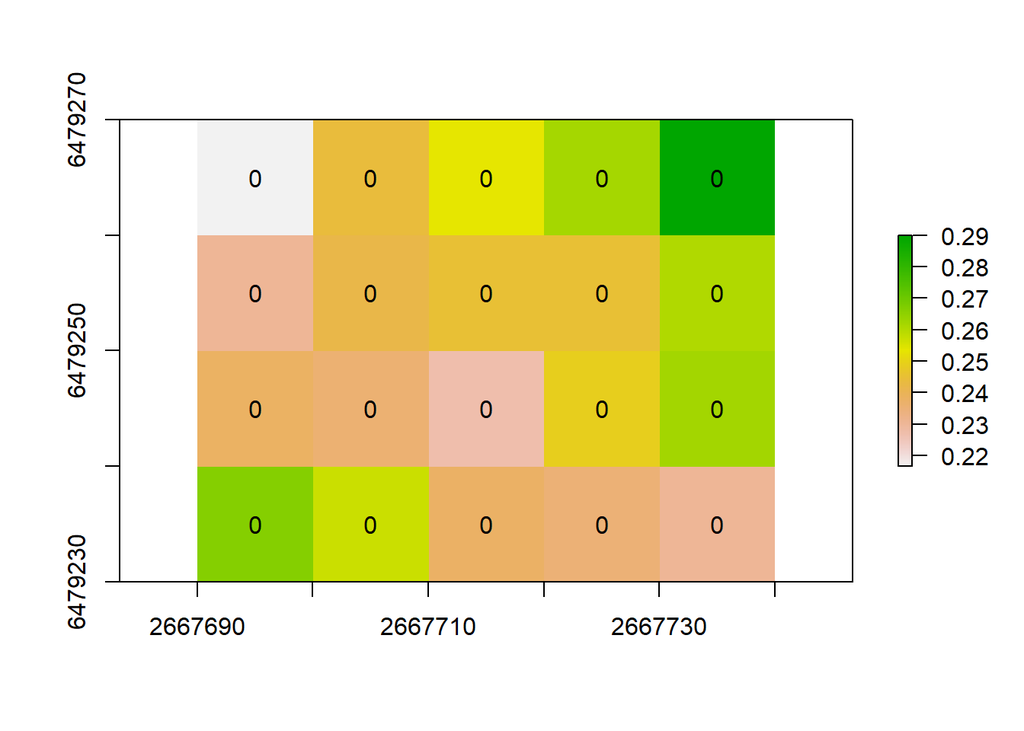

```r
plot(raster(slope))
text(raster(slope))
```

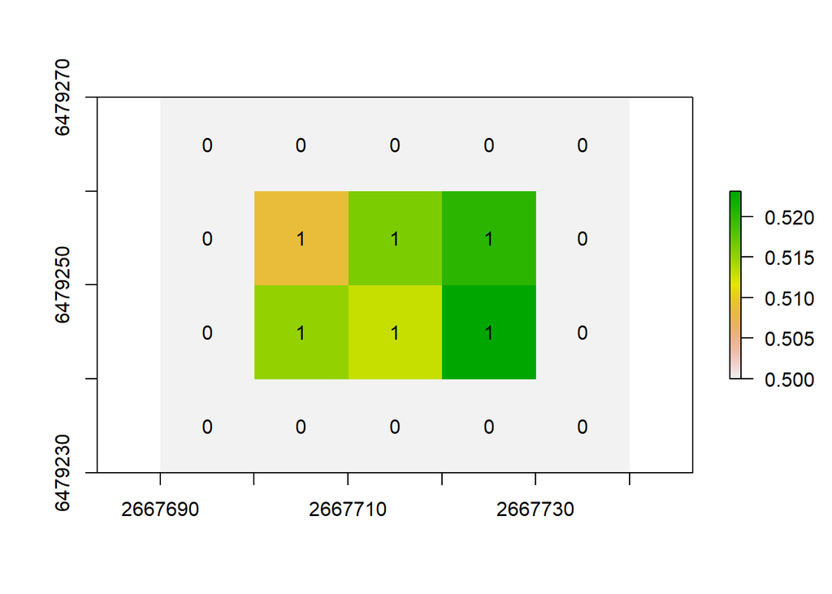

```r
plot(raster(trans_reclass))
text(raster(trans_reclass))
```

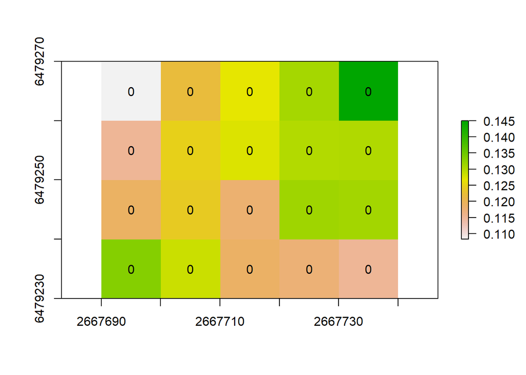

```r
plot(raster(final_cost))
text(raster(final_cost))
```

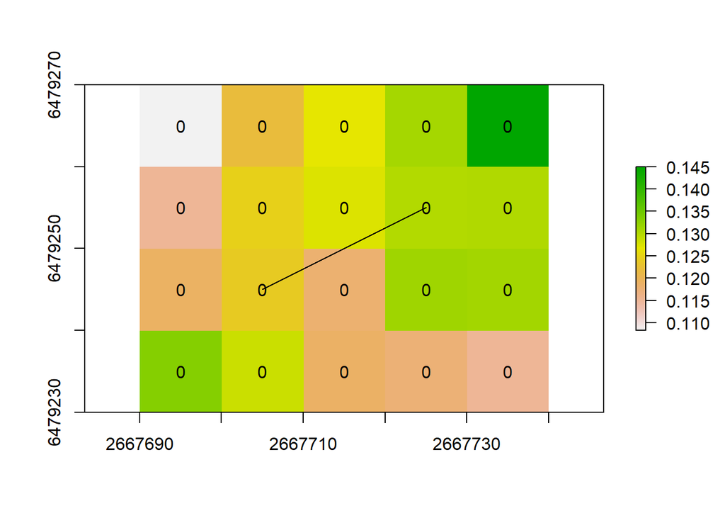

```r
lcp <- gdistance::shortestPath(final_cost, c(2667705, 6479244), c(2667724, 6479256), output = "SpatialLines")

plot(raster(final_cost))
text(raster(final_cost))
plot(lcp, add = T)
```